# Covid Analysis Report

2025-04-25

## Introduction

This report summarizes findings from an analysis of COVID-19 patient data in Mexico. The dataset includes demographic and clinical features of over a million patients, with a 20% subset used for initial analysis. We focused on how age and pre-existing health conditions relate to COVID-19 mortality using descriptive visualizations and logistic regression modeling. All results in this report were generated ahead of time and saved in the `output/` folder for reproducibility.

## COVID-19 Mortality by Age Group

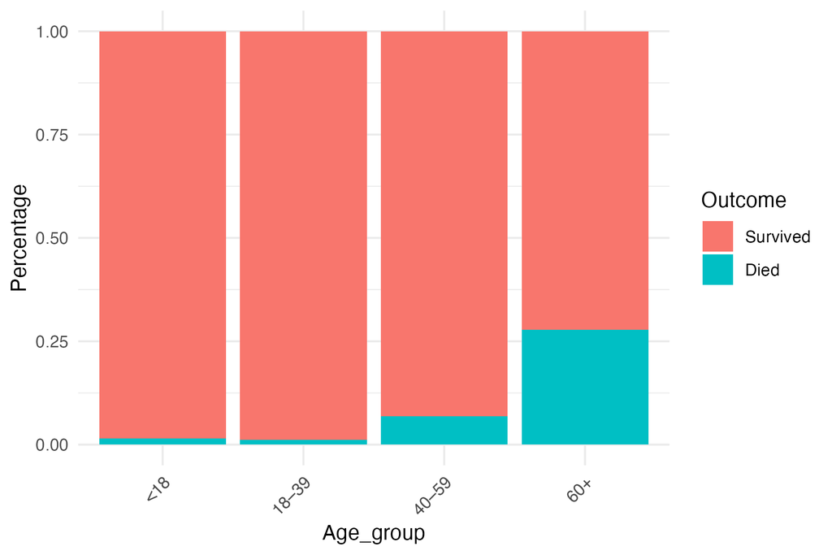

This bar chart illustrates the relationship between patient age group and COVID-19 mortality outcome. Younger age groups (<18, 18–39) had very low death proportions, whereas mortality increased significantly in the 40–59 group and was highest among individuals aged 60 and above. These results highlight age as a critical factor in predicting COVID-19 severity.

## Logistic Regression Model of Mortality Risk

Logistic Regression Coefficients for COVID-19 Mortality

| term | estimate | std.error | statistic | p.value |
| --- | --- | --- | --- | --- |
| (Intercept) | -6.34 | 0.04 | -170.10 | <0.001 |
| age | 0.07 | 0.00 | 107.03 | <0.001 |
| diabetesYes | 0.64 | 0.02 | 28.94 | <0.001 |
| asthmaYes | -0.37 | 0.06 | -5.66 | <0.001 |
| inmsuprYes | 0.66 | 0.06 | 11.56 | <0.001 |
| hipertensionYes | 0.22 | 0.02 | 10.14 | <0.001 |
| cardiovascularYes | -0.03 | 0.05 | -0.69 | 0.489 |
| obesityYes | 0.35 | 0.02 | 14.94 | <0.001 |
| tobaccoYes | 0.03 | 0.03 | 0.84 | 0.401 |
| renal_chronicYes | 0.82 | 0.04 | 18.95 | <0.001 |

We fitted a logistic regression model to predict the likelihood of death (death_indicator) based on demographic and clinical factors. Key findings:

Age has a strong positive association with mortality (p < 0.001).

Chronic conditions such as diabetes, hypertension, immunosuppression, obesity, and renal disease significantly increase the risk of death.

Asthma was negatively associated with death (p < 0.001).

Tobacco use and cardiovascular disease were not significant predictors in this model (p > 0.05).